# simulation_BLMM

Xiujuan Wen, Panwan Ke, Haiyang Jin

2022-07-25

# 应用示例

```r
# 加载模拟数据
# 具体数据模拟代码请参考，数据模拟代码.R
load("simulated_data.rdata")
```

## 数据预处理

接下来我们使用R的brms工具包建构和拟合贝叶斯线性混合效应模型（Bürkner，2017；Ladislas et al.，2019；Vasishth et al.，2018）。brms工具包凭借其与lme4相似的语法 （Bates, Mächler, et al.，2015）和强大的扩展功能等优势受到许多研究者的青睐，是目前比较流行的贝叶斯数据分析工具之一。 在使用brms工具包分析数据之前，我们需要对模拟的数据集进行一些预处理。首先，大部分流行的统计软件（例如SPSS）通常分析的是“宽”（wide）数据，即每一行是一个被试的数据。相比之下，brms以及其他一些R语言的工具包通常处理的是“长”（long）数据，即每一行是一个试次的数据。因此，我们需要将数据集 df_simu 整理为“长数据”格式，如下所示：

```r
head(df_simu, 10) # 查看数据结构
```

| subj | group | type | LPP |
| --- | --- | --- | --- |
| subj01 | depression | netural | -1.635569 |
| subj01 | depression | netural | -3.996605 |
| subj01 | depression | netural | -1.527243 |
| subj01 | depression | netural | -3.220246 |
| subj01 | depression | netural | -4.339016 |
| subj01 | depression | netural | 1.487975 |
| subj01 | depression | netural | -3.462970 |
| subj01 | depression | netural | 2.930028 |
| subj01 | depression | netural | -3.273642 |
| subj01 | depression | netural | -1.440517 |

此外，我们还需要对数据集df_simu中的称名（自）变量（nominal factors）进行编码（contrast coding）。这里我们使用逐次差分对比编码（即R中的 `MASS::contr.sdif()`） 对组别（`group`） 和图片类型（`type`） 这两个自变量进行编码。通过此设定，贝叶斯模型的输出结果刚好对应大部分研究者熟悉的主效应和交互作用。

```r
# 设定-0.5和0.5的编码
contrasts(df_simu$group) <- MASS::contr.sdif(2)
contrasts(df_simu$type) <- MASS::contr.sdif(2)
```

## 只有固定效应的模型

在建立贝叶斯线性混合效应模型时，研究者需要考虑如何设定固定效应和随机效应。我们首先建立最简单的模型，即一个仅包含固定效应的模型（`model_1`）。具体来说，我们将组别 (`group`) 和图片类型 (`type`) 两个自变量以及他们的交互作用作为固定效应。该模型假定所有被试的平均波幅都是相同的，且图片类型对于每个被试的影响也是相同的。

```r
# 建立只有固定效应的模型
model_1 <- brm(
  LPP ~ group * type,
  data = df_simu,
  chains = 4,
  warmup = 1000,
  iter = 5000,
  thin = 1,
  cores = 4,
  # 注意：正文中没有以下代码
  seed = 2022,                  # 该参数的设置是为了读者能获得和正文相同的结果
  file = "brm_fit/model_1.Rds"  # 设置该参数可以让读者保存运行的模型，避免重复计算
)
```

在上述代码中，`LPP`是因变量，即被试观看不同图片时LPP的波幅，`group * type`表示组别 `group`和图片类型`type`两个自变量的主效应以及他们的交互作用。 `df_simu`为数据集。其他参数是模型拟合时所基于的MCMC采样算法的相关参数。为了保证后验分布的有效性，MCMC通常会同时运行多个独立的采样过程，每个独立的采样过程称为一条链（chain）。只有当各个独立链的抽样“融合”在一起时（详见下文），MCMC获得的参数后验分布才更可能是有效的 (McElreath, 2020)。在`model_1`中，我们设置了4条链 （默认为4）。与之相对应的是cores参数，它可以设定运行MCMC时使用的计算机中央处理器核心（Central Processing Unit cores）的个数。`cores=4`（默认为1）表示使用4个中央处理器核心同时分别各运行1条马尔可夫链（共4条链），借此提高数据分析的速度。 `iter`参数（iteration的简写）指的是每条链的迭代次数，即对每个参数进行多少次的抽样(sample)。`warmup`参数（或称为burn in）设定了在每条链采样的开始阶段用于“校准”的迭代次数。因此，每条链最后保留的采样数量为`iter` 和`warmup`的差值。例如，在`model_1`中每一条链会对每个参数抽取4000个样本（即5000-1000），4条链一共会对每个参数抽取16000个样本。 通过`summary()`函数可以展示模型拟合的相关参数和结果：

```r
summary(model_1) # 可以查看参数情况
```

```
 Family: gaussian
  Links: mu = identity; sigma = identity
Formula: LPP ~ group * type
   Data: df_simu (Number of observations: 4800)
  Draws: 4 chains, each with iter = 5000; warmup = 1000; thin = 1;
         total post-warmup draws = 16000

Population-Level Effects:
                 Estimate Est.Error l-95% CI u-95% CI Rhat Bulk_ESS Tail_ESS
Intercept            0.68      0.04     0.59     0.77 1.00    20704    11970
group2M1             0.28      0.09     0.11     0.45 1.00    22795    11855
type2M1              6.50      0.09     6.33     6.67 1.00    22947    12313
group2M1:type2M1     0.02      0.17    -0.33     0.35 1.00    20767    12123

Family Specific Parameters:
      Estimate Est.Error l-95% CI u-95% CI Rhat Bulk_ESS Tail_ESS
sigma     3.03      0.03     2.97     3.09 1.00    22944    13150

Draws were sampled using sampling(NUTS). For each parameter, Bulk_ESS
and Tail_ESS are effective sample size measures, and Rhat is the potential
scale reduction factor on split chains (at convergence, Rhat = 1).
```

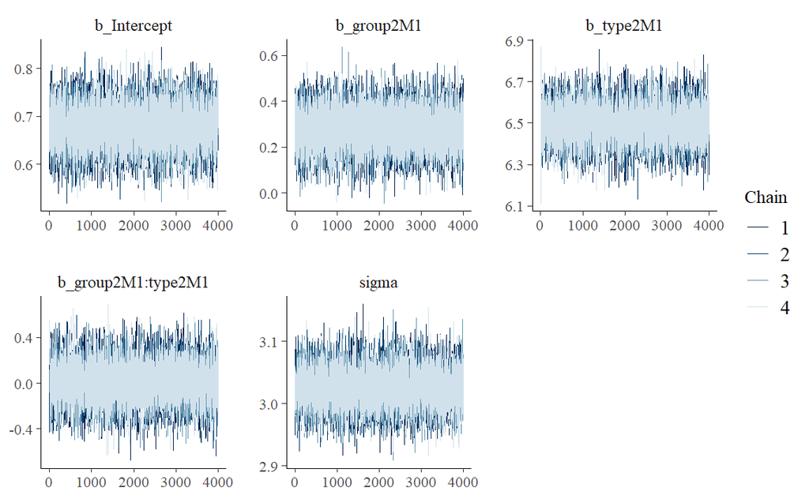

```r
mcmc_trace(model_1, pars = c("b_Intercept", "b_group2M1", "b_type2M1", "b_group2M1:type2M1", "sigma"))
```

## 添加随机效应

如前所述，仅包含固定效应的模型（`model_1`）假定所有被试的平均脑电波幅都是相同的，即所有被试共享同一个截距值。但这种情况在现实中不太可能发生。更可能的情况是，每个被试的平均脑电波幅都各不相同。因此，我们需要在模型中增加随机截距来考虑被试在平均脑电波幅上的个体差异。具体来说，我们需要在`model_1`的基础上增加基于被试（by-subject）的随机截距（对应公式2中的$S_{(0,i)}$），即 `(1 | subj)`。其中`subj`为被试编号，`1`表示随机截距：

```r
model_2 <- brm(
  LPP ~ group * type + (1 | subj),
  data = df_simu,
  chains = 4,
  warmup = 1000,
  iter = 5000,
  thin = 1,
  cores = 4,
  # 注意：正文中没有以下代码
  seed = 2022,                  # 该参数的设置是为了读者能获得和正文相同的结果
  file = "brm_fit/model_2.Rds"  # 设置该参数可以让读者保存运行的模型，避免重复计算
)
```

```r
summary(model_2) # 查看参数情况
```

```
 Family: gaussian
  Links: mu = identity; sigma = identity
Formula: LPP ~ group * type + (1 | subj)
   Data: df_simu (Number of observations: 4800)
  Draws: 4 chains, each with iter = 5000; warmup = 1000; thin = 1;
         total post-warmup draws = 16000

Group-Level Effects:
~subj (Number of levels: 80)
              Estimate Est.Error l-95% CI u-95% CI Rhat Bulk_ESS Tail_ESS
sd(Intercept)     2.16      0.18     1.84     2.55 1.00     1203     1803

Population-Level Effects:
                 Estimate Est.Error l-95% CI u-95% CI Rhat Bulk_ESS Tail_ESS
Intercept            0.67      0.23     0.21     1.13 1.01      623      879
group2M1             0.31      0.51    -0.70     1.32 1.00      646     1093
type2M1              6.50      0.06     6.37     6.62 1.00    15141    11362
group2M1:type2M1     0.02      0.13    -0.23     0.26 1.00    13358     9887

Family Specific Parameters:
      Estimate Est.Error l-95% CI u-95% CI Rhat Bulk_ESS Tail_ESS
sigma     2.18      0.02     2.14     2.22 1.00    17487    11722

Draws were sampled using sampling(NUTS). For each parameter, Bulk_ESS
and Tail_ESS are effective sample size measures, and Rhat is the potential
scale reduction factor on split chains (at convergence, Rhat = 1).
```

`Population-Level Effects`为model_2固定效应的结果，其相关参数的含义与`model_1`中的相同（详见3.2 部分）。`Group-Level Effects`为随机效应结构的结果，其中`sd(Intercept)` 为随机截距的标准差，反映了LPP平均波幅在不同被试间的离散程度。

## 添加随机斜率

虽然`model_2`考虑了不同被试平均LPP波幅的个体差异，但它仍然假定所有被试受到实验处理（即图片类型）的影响是相同的。然而在实际情况中，每个被试受到图片类型的影响更可能是不同的。因此，我们需要设置随机斜率考虑图片类型对不同被试的不同影响。具体来说，我们可以在`model_2`模型的基础之上加入随机斜率（对应公式3中的$S_{(δ,i)}$），即`(type | subj)`，其中`subj`为被试编号， `type`为图片类型的随机斜率。与此同时，我们也在模型中加入了随机截距与随机斜率间的相关:

```r
model_3 <- brm(
  LPP ~ group * type + (1 + type | subj),
  data = df_simu,
  chains = 4,
  warmup = 1000,
  iter = 5000,
  thin = 1,
  cores = 4,
  # 注意：正文中没有以下代码
  seed = 2022,                  # 该参数的设置是为了读者能获得和正文相同的结果
  file = "brm_fit/model_3.Rds"  # 设置该参数可以让读者保存运行的模型，避免重复计算
)
```

```r
summary(model_3) # 查看参数情况
```

```
 Family: gaussian
  Links: mu = identity; sigma = identity
Formula: LPP ~ group * type + (1 + type | subj)
   Data: df_simu (Number of observations: 4800)
  Draws: 4 chains, each with iter = 5000; warmup = 1000; thin = 1;
         total post-warmup draws = 16000

Group-Level Effects:
~subj (Number of levels: 80)
                       Estimate Est.Error l-95% CI u-95% CI Rhat Bulk_ESS Tail_ESS
sd(Intercept)              2.17      0.18     1.86     2.55 1.00     1151     2404
sd(type2M1)                1.82      0.16     1.53     2.16 1.00     2783     5543
cor(Intercept,type2M1)     0.32      0.11     0.10     0.52 1.00     1737     3516

Population-Level Effects:
                 Estimate Est.Error l-95% CI u-95% CI Rhat Bulk_ESS Tail_ESS
Intercept            0.68      0.24     0.19     1.14 1.01      623     1239
group2M1             0.27      0.47    -0.64     1.21 1.01      630     1343
type2M1              6.49      0.21     6.08     6.90 1.00     1535     3228
group2M1:type2M1     0.00      0.42    -0.84     0.84 1.00     1595     3085

Family Specific Parameters:
      Estimate Est.Error l-95% CI u-95% CI Rhat Bulk_ESS Tail_ESS
sigma     1.99      0.02     1.95     2.03 1.00    19954    11300

Draws were sampled using sampling(NUTS). For each parameter, Bulk_ESS
and Tail_ESS are effective sample size measures, and Rhat is the potential
scale reduction factor on split chains (at convergence, Rhat = 1).
```

与`model_2`结果相比， `model_3`中的 `Group-Level Effects`部分额外展示了基于被试的随机斜率和他与随机截距相关性的后验分布情况。其中，`sd(type2M1)` 为基于被试的图片类型随机斜率的标准差，反映了不同被试LPP波幅受到图片类型不同影响的离散程度。`cor(Intercept, type2M1)` 为随机截距和随机斜率的相关，该相关结果表明两者之间存在一定的正相关，即平均LPP波幅更大的被试，其对积极图片的LPP波幅也比中性图片更大。 或许有研究者会考虑是否也应该在模型中增加组别的随机斜率。但由于在该实验中，每名被试只参加了实验组或控制组，所以我们无法估计组别的随机斜率。一般来讲，研究者应该为感兴趣的所有被试内因素设定随机效应，而不需要为被试间因素设定随机效应。

至此，我们完成了对该模拟数据的模型构建，即根据实验设计设定了所有合理的固定效应和随机效应结构。在该示例中，我们从仅包含固定效应的线性模型出发，在不同的模型中依次展示了如何添加随机截距和随机斜率。但在实际的贝叶斯数据分析中，研究者只需要根据实验设计直接设定最合理的模型，而无需在不同的模型中依次添加不同的随机效应。

## 先验的设置

贝叶斯分析的一大优势是可以通过设定先验分布在数据分析中整合研究者的先验知识。由于我们在先前建立的模型（例如`model_3`）中没有自定义先验分布，因此它们使用的是brms的默认先验分布。这些先验分布通常是无信息先验（noninformative prior），即相对实验数据来讲，基本不能为参数估计提供有效信息的先验 (Seaman et al., 2012)。使用这些默认的无信息先验不仅不能发挥贝叶斯数据分析的最大作用，甚至可能会对数据分析的结果产生负面的影响 (Seaman et al., 2012)。例如，贝叶斯因子很容易受到先验分布的影响，不合理的先验会导致有偏差的贝叶斯因子。因此，为贝叶斯分析设定合理的先验至关重要。

先验分布是研究者以概率分布的形式描述自己关于特定研究问题的先验知识。它赋予了模型参数在观测到数据之前的相对合理性。这些先验信息与观测数据的信息相互整合成为模型参数的后验分布。作为设定先验分布的第一步，研究者需要知道自己可以对一个模型的哪些参数设置先验。这里可以借助`get_prior()`函数得到相应的信息：

```r
get_prior(
  LPP ~ group * type + (1 + type | subj),
  data = df_simu
)
```

```
                prior     class             coef group resp dpar nlpar lb ub       source
               (flat)         b                                                   default
               (flat)         b         group2M1                             (vectorized)
               (flat)         b group2M1:type2M1                             (vectorized)
               (flat)         b          type2M1                             (vectorized)
               lkj(1)       cor                                                   default
               lkj(1)       cor                   subj                       (vectorized)
 student_t(3, 0.5, 5) Intercept                                                   default
   student_t(3, 0, 5)        sd                                         0         default
   student_t(3, 0, 5)        sd                   subj                  0    (vectorized)
   student_t(3, 0, 5)        sd        Intercept  subj                  0    (vectorized)
   student_t(3, 0, 5)        sd          type2M1  subj                  0    (vectorized)
   student_t(3, 0, 5)     sigma                                         0         default
```

如结果所示，我们可以为`model_3`模型的以下参数设定先验：固定截距（`class`为`Intercept`)，固定斜率（`class`为`b`的参数，包含`coef`为`group2M1`, `group2M1:type2M1`和`type2M1`），基于被试（`group`为`subj`）的随机效应的标准差（`class`为`sd`，包含随机截距`coef`为`Intercept` 和随机斜率`coef`为`type2M1`），基于被试的随机效应间的相关（`class`为`cor`），以及残差（`class`为`sigma`）。由于`sd`和`sigma`不能为负数，因此这些参数的最小值为0（即列`lb`，为low bound的缩写）。

在实际数据分析中，研究者一般可以根据以往研究的结果为当前研究的模型设定先验分布。如果可以从先前类似的研究获得参数的后验概率分布，研究者可以将这些概率分布作为当前研究模型的先验分布。即使无法获得参数准确的概率分布，研究者仍然可以根据先前研究结果以及自己已有的知识为模型设定先验分布。此时，研究者可以通过先验预测检验（prior predictive check）来测试这些先验的合理性，并进行相应的调整，进而为模型确定合理的先验。

假设我们无法从先前研究中获取参数的概率分布作为模型的先验。此时，我们也可以凭借已有的经验为模型设定先验。比如，我们首先尝试设置无信息或弱信息的先验分布：

```r
## 定义先验分布
prior_01 <- c(
  prior(normal(0, 10), class = Intercept),
  prior(normal(0, 10), class = b),
  prior(normal(0, 5), class = sigma),
  prior(normal(0, 5), class = sd),
  prior(lkj(2), class = cor)
)
```

在上述代码中，我们把固定截距和固定斜率分别设定为一个均值为0，标准差为10的正态分布（在代码中表示为`normal(0, 10)`）。对于`prior(normal(0, 10), class = Intercept)`，我们可以简单地把它理解为，我们设定所有被试的平均值脑电波幅大致有95%的概率落在-20和20之间（即两个标准差之内）。对于平均脑电波幅来讲，这是一个相对比较大的区间。因此，它对应的先验分布是一个无信息或弱信息的先验分布。类似地，固定斜率，包含组别和图片类型的主效应以及他们的交互作用，也大致落在相同的区间。尽管固定斜率的先验是无信息或弱信息先验，但这些先验（即`normal(0, 10)`） 仍然比`brms`中的默认先验（它对应的区间大约是负无穷到正无穷）提供了更多的信息。此外需要注意的是，尽管我们使用正态分布作为残差sigma和随机效应的标准差sd设置先验，但由于这些参数不能小于0，因此他们使用的实际先验分布是截断正态分布（truncated normal distribution）。最后，为随机效应间的相关性设置的是弱信息先验 `prior(lkj(2), class = cor)` ，其中lkj为LKJ相关性矩阵 (LKJ-Correlation prior matrix) (Lewandowski et al., 2009)。 为了检验先验分布的合理性，我们可以使用先验预测检验审查只使用先验信息时因变量（即LPP的波幅）的情况。进行先验预测检验需要对先验分布进行采样（sample），即在模型中设定设定先验分布（`prior=prior_01`）的基础上加入`sample_prior ="only"`。其余参数的设定和我们在分析数据时设定相同（例如`model_3`），具体代码如下：

```r
model_ppc_01 <- brm(
  LPP ~ group * type + (1 + type | subj),
  data = df_simu,
  chains = 4,
  warmup = 1000,
  iter = 5000,
  thin = 1,
  cores = 4,
  prior = prior_01,
  sample_prior = "only",
  # 注意：正文中没有以下代码
  seed = 2022                 # 该参数的设置是为了读者能获得和正文相同的结果
)
```

通过上述代码，我们可以获得16，000组（（5000-1000）*4）来自参数先验分布的抽样，每一组都包含模型的所有参数（比如固定截距，固定斜率，随机效应等）各一个。每一组的参数都可以使用数据集（`df_simu`）中的实验设计生成一套新的、仅基于先验分布的模拟观测数据。我们可以通过审查这些模拟生成的数据去判断先验设定是否合适。例如在一个以反应时为因变量的 stroop 实验中，如果那些由先验分布生成的模拟反应时大多数都长于预期（比如10s），这很可能说明模型某些参数先验的设定不太合理（比如截距数值太大或标准差过大）。幸运的是，上述复杂的过程可以借助`pp_check()`函数完成。 如前文所述，尽管我们无法根据先前研究设定精确的先验，但是我们拥有一定的先验知识，了解脑电事件相关电位的波幅通常在一定的范围之内。因此，我们计算16，000套由先验分布生成的模拟数据的最小值（min）、平均数（mean）和最大值（max），并检验他们的范围：

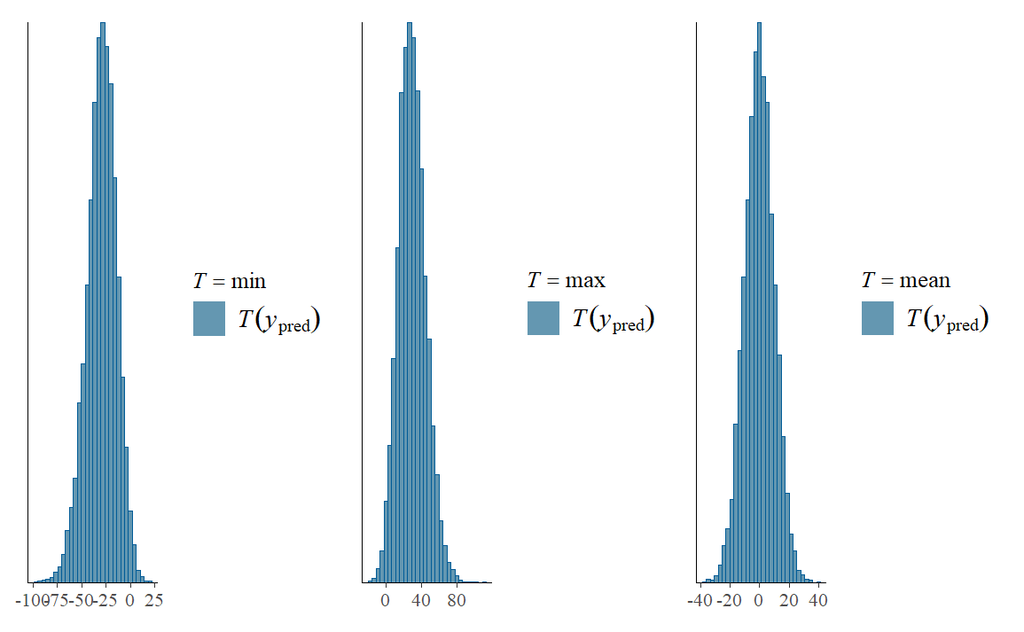

结果显示，基于`prior_01`生成的每一套模拟观测数据的最小值大部分落在[-75, 0]，均值大部分落在[-25, 25]，而最大值大部分落在[0, 80]。根据我们有限的实验经验，试次水平的脑电波幅通常很少会超过-50（μV）或50（μV）（伪迹除外）。因此，我们可以适当的调整参数的先验分布以反映我们的先验知识，即减小参数先验分布的不确定性。故在第二次尝试中，我们将固定截距和固定斜率的先验设置成均值为0，标准差为5的正态分布：

```r
## 定义先验分布
prior_02 <- c(
  prior(normal(0, 5), class = Intercept),
  prior(normal(0, 5), class = b),
  prior(normal(0, 5), class = sigma),
  prior(normal(0, 5), class = sd),
  prior(lkj(2), class = cor)
)
model_ppc_02 <- brm(
  LPP ~ group * type + (1 + type | subj),
  data = df_simu,
  chains = 4,
  warmup = 1000,
  iter = 5000,
  thin = 1,
  cores = 4,
  prior = prior_02,
  sample_prior = "only",
  # 注意：正文中没有以下代码
  seed = 2022                 # 该参数的设置是为了读者能获得和正文相同的结果
)
```

```r
a1 = pp_check(model_ppc_02, type = "stat", stat = "min", prefix = "ppd")
```

```
Using all posterior draws for ppc type 'stat' by default.
```

```r
a2 = pp_check(model_ppc_02, type = "stat", stat = "max", prefix = "ppd")
```

```
Using all posterior draws for ppc type 'stat' by default.
```

```r
a3 = pp_check(model_ppc_02, type = "stat", stat = "mean", prefix = "ppd")
```

```
Using all posterior draws for ppc type 'stat' by default.
```

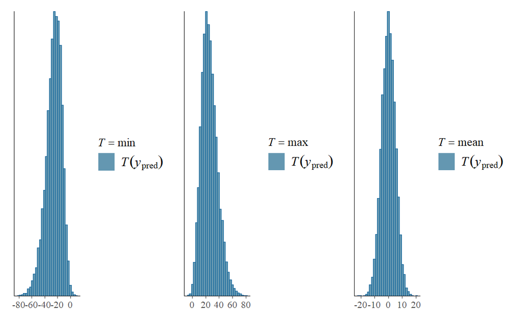

```r
fig4_ppc = a1 + a2 + a3
ggsave("fig4_ppc.tiff", fig4_ppc,
       width = 10, height = 4, bg = "white",
       dpi = 300, compression = "lzw")
fig4_ppc
```

经过同样的步骤，我们可以获得基于先验`prior_02`生成的16，000套模拟观测数据（`y(rep)`）的最小值、均值和最大值的分布（图 3）。结果显示这些模拟观测数据的最小值大部分落在[-60, 0]，均值大部分落在了[-10, 10]，最大值大部分落在[0, 60]。与`prior_01`的先验预测结果（图 2）相比，prior_02预测结果更多落在了[-50, 50]，能够相对更合理的描述我们的先验知识。 合理的先验设定通常需要重复多次类似的过程，且并不是先验分布的信息越强就越好，它需要合理反映研究者的先验知识。值得注意的是，先验分布描述的是研究者在观测到数据之前的知识。因此，研究者可以借助预注册（pre-registration）等方法为先验分布提供客观性证据。

确定合理的先验分布通常需要重复多次类似的过程，且并不是先验分布的信息越强就越好，它需要合理反映研究者的先验知识。在确定合理的先验分布后，我们可以利用该先验进行模型拟合，即在`model_ppc_02`的基础上删除`sample_prior ="only"`或将其更新为`sample_prior ="yes"`。我们将新的模型命名为`model_4`：

```r
model_4 <- brm(
  LPP ~ group * type + (1 + type | subj),
  data = df_simu,
  chains = 4,
  warmup = 1000,
  iter = 5000,
  thin = 1,
  cores = 4,
  prior = prior_02,
  sample_prior = "yes",
  # 注意：正文中没有以下代码
  seed = 2022,                  # 该参数的设置是为了读者能获得和正文相同的结果
  file = "brm_fit/model_4.Rds"  # 设置该参数可以让读者保存运行的模型，避免重复计算
)
```

```r
summary(model_4)
```

```
 Family: gaussian
  Links: mu = identity; sigma = identity
Formula: LPP ~ group * type + (1 + type | subj)
   Data: df_simu (Number of observations: 4800)
  Draws: 4 chains, each with iter = 5000; warmup = 1000; thin = 1;
         total post-warmup draws = 16000

Group-Level Effects:
~subj (Number of levels: 80)
                       Estimate Est.Error l-95% CI u-95% CI Rhat Bulk_ESS Tail_ESS
sd(Intercept)              2.16      0.18     1.85     2.54 1.00     1112     2707
sd(type2M1)                1.81      0.16     1.53     2.15 1.00     2626     5004
cor(Intercept,type2M1)     0.31      0.11     0.10     0.51 1.00     2082     3882

Population-Level Effects:
                 Estimate Est.Error l-95% CI u-95% CI Rhat Bulk_ESS Tail_ESS
Intercept            0.67      0.24     0.18     1.13 1.01      656     1246
group2M1             0.27      0.49    -0.70     1.21 1.00      610     1141
type2M1              6.48      0.21     6.07     6.90 1.00     1569     3145
group2M1:type2M1     0.00      0.43    -0.83     0.87 1.00     1247     2556

Family Specific Parameters:
      Estimate Est.Error l-95% CI u-95% CI Rhat Bulk_ESS Tail_ESS
sigma     1.99      0.02     1.95     2.03 1.00    19015    12160

Draws were sampled using sampling(NUTS). For each parameter, Bulk_ESS
and Tail_ESS are effective sample size measures, and Rhat is the potential
scale reduction factor on split chains (at convergence, Rhat = 1).
```

与`model_3`相比，`mode_4`设定了使用先验`prior_02`，且在抽取后验样本的同时，也抽取了先验样本（即`sample_prior ="yes"`）。这样的设定可以为我们下一步借助贝叶斯因子进行假设检验奠定基础。

## 贝叶斯因子

在实际应用中，研究者通常感兴趣的是实验条件之间是否存在差异，比如本研究中的组别（组间因素）和图片类型（被试内因素）是否会对LPP产生影响。探索这类问题的一种常用方法是使用贝叶斯因子。贝叶斯因子可以量化基于不同的假设或模型（例如零假设和备择假设）观测到当前数据的相对似然 (Rouder et al., 2018)，研究者可以根据其数值大小判断观测到的数据更可能支持哪种假设或模型。一种流行的计算贝叶斯因子的方法是 Dickey Savage density ratio (Heck, 2019; Wagenmakers et al., 2010)。它可以通过`brms`提供的`hypothesis()`函数实现。我们首先利用贝叶斯混合效应模型的拟合结果（`model_4`）检验图片类型是否会对LPP产生影响：

```r
# 组内比较
result <- hypothesis(model_4, "type2M1=0")
result$hypothesis$Evid.Ratio # 查看贝叶斯因子BF_01
```

```
[1] 1.629488e-15
```

接下来，我们检验LPP在不同组别间的差异是否为0:

```r
# 组间比较
result <- hypothesis(model_4, "group2M1=0")
result$hypothesis$Evid.Ratio # 查看贝叶斯因子BF_01
```

```
[1] 8.865514
```

此外，我们还可以检验交互作用是否为0:

```r
result <- hypothesis(model_4, "group2M1:type2M1=0")
result$hypothesis$Evid.Ratio # 查看贝叶斯因子BF_01
```

```
[1] 11.88946
```

“`group2M1:type2M1=0`”表示组别（`group`）和图片类型（`type`）交互作用的零假设，即抑郁组中积极图片和中性图片LPP波幅差异与对照组中积极图片和中性图片LPP波幅差异的差异（即差的差）为0。结果显示，$BF_{01}$=11.90>10，这表明存在较强的证据支持交互作用的零假设。